# Redstripe Rockfish

*Sebastes proriger*

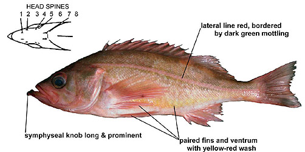

**Body color:** Light red, mottled w/ olive dorsally and flushed w/ yellow on lower sides; lateral line in a clear, light-red zone, bordered by dark olivaceous mottling; lips blackened.

**Peritoneum color:** dark **Shape between eyes:** convex

**Counts:** D:XIII,13-15, Ar:6-7, P1:16-18, GR:36-43, LLp:47-55, LLs:55-60, V:27

**Occurence:** Bering Sea - Baja California

**Depth:** 100-425 meters **Size:** 52 cm **Species code:** 30430

**Similar species:**

- *Yellowmouth rockfish* - symphyseal knob weaker, rounded; yellow and black blotches inside pinkish mouth; opercular blotch discrete; dorsal blotches diffuse
- *Northern rockfish* - dorsal spines typically 14 (13 in Redstripe RF); dark bars radiate posteriorly from eye; pink slash on ventral portion of pectoral fin; head spine count differs
- *Sharpchin rockfish* - dorsal blotches large w/ at least one extending across lateral line; forked bar radiates posteriorly from eye; head spines strong and count differs;anal spine 2 longer 3
- *Pacific Ocean Perch* - lateral line not bordered by mottling; head spine count typically differs
- *Chilipepper* - dorsal blotches absent; lateral line not bordered by mottling; peritoneum light; head spine count differs; belly whitish

Back to Group

**Corrections:** If you see mistakes or want to suggest changes, please create an [issue](https://github.com/zoyafuso-NOAA/RACE_Survey_App/issues) on the source repository or

*reach out to Liz Dawson (Liz.Dawson AT noaa.gov).*